# si544-day3-data-wrangling-inclass

Matt Garvin

9/18/2020

First, let’s load the libraries we’ll need (missing libraries? use install.packages() to install them:

```r
library(dplyr)
```

```r
library(ggplot2)
library(readr)
library(tidyr)
library(nycflights13)
library(fivethirtyeight)
```

## Pipes

```r
values <- c(1,2,3)
```

The usual approach is to pass the data frame as an argument, that is:

```r
sum(values)
```

```
## [1] 6
```

Using pipes, we can say “take values then apply sum”:

```r
values %>% sum
```

```
## [1] 6
```

## Filtering

(You might want to View(flights) in the Console.)

```r
alaska_flights <- flights %>%
   filter(carrier == "AS")
```

```r
portland_flights <- flights %>%
   filter(dest == "PDX")
```

```r
btv_sea_flights_fall <- flights %>%
   filter(origin == "JFK" & (dest == "BTV" | dest == "SEA") & month >= 10)
```

We can use ‘,’ instead of ‘&’:

```r
btv_sea_flights_fall <- flights %>%
   filter(origin == "JFK", (dest == "BTV" | dest == "SEA"), month >= 10)
```

```r
not_BTV_SEA <- flights %>%
 filter(!(dest == "BTV" | dest == "SEA"))
```

Oops:

```r
flights %>%
 filter(!dest == "BTV" | dest == "SEA")
```

```
## # A tibble: 334,187 x 19
##     year month   day dep_time sched_dep_time dep_delay arr_time sched_arr_time
##    <int> <int> <int>    <int>          <int>     <dbl>    <int>          <int>
##  1  2013     1     1      517            515         2      830            819
##  2  2013     1     1      533            529         4      850            830
##  3  2013     1     1      542            540         2      923            850
##  4  2013     1     1      544            545        -1     1004           1022
##  5  2013     1     1      554            600        -6      812            837
##  6  2013     1     1      554            558        -4      740            728
##  7  2013     1     1      555            600        -5      913            854
##  8  2013     1     1      557            600        -3      709            723
##  9  2013     1     1      557            600        -3      838            846
## 10  2013     1     1      558            600        -2      753            745
## # ... with 334,177 more rows, and 11 more variables: arr_delay <dbl>,
## #   carrier <chr>, flight <int>, tailnum <chr>, origin <chr>, dest <chr>,
## #   air_time <dbl>, distance <dbl>, hour <dbl>, minute <dbl>, time_hour <dttm>
```

Lots of ‘|’ (or) operators:

```r
many_airports <- flights %>%
 filter(dest == "BTV" | dest == "SEA" | dest == "PDX" |
        dest == "SFO" | dest == "BDL")
```

The ‘%in%’ operator can replace lots of ‘|’ operators:

```r
many_airports <- flights %>%
 filter(dest %in% c("BTV", "SEA", "PDX", "SFO", "BDL"))
```

## (LC 544.3.1)

Write code to create a dataframe containing only those flights arriving at Detroit (airport code DTW)

```r
# INSERT YOUR R CODE HERE
detroit_flights <- flights %>% filter(dest == "DTW")
```

# Summarization

```r
summary_temp <- weather %>%
  summarize(mean = mean(temp), std_dev = sd(temp))
summary_temp
```

```
## # A tibble: 1 x 2
##    mean std_dev
##   <dbl>   <dbl>
## 1    NA      NA
```

```r
summary_temp <- weather %>%
  summarize(mean = mean(temp, na.rm = TRUE),
            std_dev = sd(temp, na.rm = TRUE))
summary_temp
```

```
## # A tibble: 1 x 2
##    mean std_dev
##   <dbl>   <dbl>
## 1  55.3    17.8
```

# Grouping

```r
summary_monthly_temp <- weather %>%
  group_by(month) %>%
  summarize(mean = mean(temp, na.rm = TRUE),
            std_dev = sd(temp, na.rm = TRUE))
summary_monthly_temp
```

```
## # A tibble: 12 x 3
##    month  mean std_dev
##    <int> <dbl>   <dbl>
##  1     1  35.6   10.2
##  2     2  34.3    6.98
##  3     3  39.9    6.25
##  4     4  51.7    8.79
##  5     5  61.8    9.68
##  6     6  72.2    7.55
##  7     7  80.1    7.12
##  8     8  74.5    5.19
##  9     9  67.4    8.47
## 10    10  60.1    8.85
## 11    11  45.0   10.4
## 12    12  38.4    9.98
```

Note that group_by doesn’t change the data.frame, only the information about the data.frame:

```r
diamonds
```

```
## # A tibble: 53,940 x 10
##    carat cut       color clarity depth table price     x     y     z
##    <dbl> <ord>     <ord> <ord>   <dbl> <dbl> <int> <dbl> <dbl> <dbl>
##  1 0.23  Ideal     E     SI2      61.5    55   326  3.95  3.98  2.43
##  2 0.21  Premium   E     SI1      59.8    61   326  3.89  3.84  2.31
##  3 0.23  Good      E     VS1      56.9    65   327  4.05  4.07  2.31
##  4 0.290 Premium   I     VS2      62.4    58   334  4.2   4.23  2.63
##  5 0.31  Good      J     SI2      63.3    58   335  4.34  4.35  2.75
##  6 0.24  Very Good J     VVS2     62.8    57   336  3.94  3.96  2.48
##  7 0.24  Very Good I     VVS1     62.3    57   336  3.95  3.98  2.47
##  8 0.26  Very Good H     SI1      61.9    55   337  4.07  4.11  2.53
##  9 0.22  Fair      E     VS2      65.1    61   337  3.87  3.78  2.49
## 10 0.23  Very Good H     VS1      59.4    61   338  4     4.05  2.39
## # ... with 53,930 more rows
```

```r
diamonds %>%
  group_by(cut)
```

```
## # A tibble: 53,940 x 10
## # Groups:   cut [5]
##    carat cut       color clarity depth table price     x     y     z
##    <dbl> <ord>     <ord> <ord>   <dbl> <dbl> <int> <dbl> <dbl> <dbl>
##  1 0.23  Ideal     E     SI2      61.5    55   326  3.95  3.98  2.43
##  2 0.21  Premium   E     SI1      59.8    61   326  3.89  3.84  2.31
##  3 0.23  Good      E     VS1      56.9    65   327  4.05  4.07  2.31
##  4 0.290 Premium   I     VS2      62.4    58   334  4.2   4.23  2.63
##  5 0.31  Good      J     SI2      63.3    58   335  4.34  4.35  2.75
##  6 0.24  Very Good J     VVS2     62.8    57   336  3.94  3.96  2.48
##  7 0.24  Very Good I     VVS1     62.3    57   336  3.95  3.98  2.47
##  8 0.26  Very Good H     SI1      61.9    55   337  4.07  4.11  2.53
##  9 0.22  Fair      E     VS2      65.1    61   337  3.87  3.78  2.49
## 10 0.23  Very Good H     VS1      59.4    61   338  4     4.05  2.39
## # ... with 53,930 more rows
```

```r
diamonds %>%
  group_by(cut) %>%
  summarize(avg_price = mean(price))
```

```
## # A tibble: 5 x 2
##   cut       avg_price
##   <ord>         <dbl>
## 1 Fair          4359.
## 2 Good          3929.
## 3 Very Good     3982.
## 4 Premium       4584.
## 5 Ideal         3458.
```

```r
by_origin <- flights %>%
  group_by(origin) %>%
  summarize(count = n())
by_origin
```

```
## # A tibble: 3 x 2
##   origin  count
##   <chr>   <int>
## 1 EWR    120835
## 2 JFK    111279
## 3 LGA    104662
```

Grouping can also be done for multiple (nested) variables. For example to group by origin and then by month:

```r
by_origin_monthly <- flights %>%
  group_by(origin, month) %>%
  summarize(count = n())
by_origin_monthly
```

```
## # A tibble: 36 x 3
## # Groups:   origin [3]
##    origin month count
##    <chr>  <int> <int>
##  1 EWR        1  9893
##  2 EWR        2  9107
##  3 EWR        3 10420
##  4 EWR        4 10531
##  5 EWR        5 10592
##  6 EWR        6 10175
##  7 EWR        7 10475
##  8 EWR        8 10359
##  9 EWR        9  9550
## 10 EWR       10 10104
## # ... with 26 more rows
```

Note that the following will not work properly:

```r
by_origin_monthly_incorrect <- flights %>%
  group_by(origin) %>%
  group_by(month) %>%
  summarize(count = n())
by_origin_monthly_incorrect
```

```
## # A tibble: 12 x 2
##    month count
##    <int> <int>
##  1     1 27004
##  2     2 24951
##  3     3 28834
##  4     4 28330
##  5     5 28796
##  6     6 28243
##  7     7 29425
##  8     8 29327
##  9     9 27574
## 10    10 28889
## 11    11 27268
## 12    12 28135
```

## (LC4.5) (LC == Learning Check)

Recall from last class’s notebook when we looked at plots of temperatures by months in NYC (Section ## Learning Check (LC3.23) ) . What does the standard deviation column in the summary_monthly_temp data frame tell us about temperatures in New York City throughout the year?

## Mutating

Creating new variables based on existing ones.

```r
weather <- weather %>%
  mutate(temp_in_C = (temp - 32) / 1.8)
```

Hmmmm. That didn’t seem to work properly. Let’s handle the “missing values” by removing them (na == “not available” or “not applicable”; rm == “remove”; therefore na.rm == "remove values that are not available).

```r
summary_monthly_temp <- weather %>%
  group_by(month) %>%
  summarize(mean_temp_in_F = mean(temp, na.rm = TRUE),
            mean_temp_in_C = mean(temp_in_C, na.rm = TRUE))
summary_monthly_temp
```

```
## # A tibble: 12 x 3
##    month mean_temp_in_F mean_temp_in_C
##    <int>          <dbl>          <dbl>
##  1     1           35.6           2.02
##  2     2           34.3           1.26
##  3     3           39.9           4.38
##  4     4           51.7          11.0
##  5     5           61.8          16.6
##  6     6           72.2          22.3
##  7     7           80.1          26.7
##  8     8           74.5          23.6
##  9     9           67.4          19.7
## 10    10           60.1          15.6
## 11    11           45.0           7.22
## 12    12           38.4           3.58
```

Calculate a new variable “gain” that is the the difference of dep_delay and arr_delay:

```r
flights <- flights %>%
  mutate(gain = dep_delay - arr_delay)
```

```r
gain_summary <- flights %>%
  summarize(
    min = min(gain, na.rm = TRUE),
    q1 = quantile(gain, 0.25, na.rm = TRUE),
    median = quantile(gain, 0.5, na.rm = TRUE),
    q3 = quantile(gain, 0.75, na.rm = TRUE),
    max = max(gain, na.rm = TRUE),
    mean = mean(gain, na.rm = TRUE),
    sd = sd(gain, na.rm = TRUE),
    missing = sum(is.na(gain))
  )
gain_summary
```

```
## # A tibble: 1 x 8
##     min    q1 median    q3   max  mean    sd missing
##   <dbl> <dbl>  <dbl> <dbl> <dbl> <dbl> <dbl>   <int>
## 1  -196    -3      7    17   109  5.66  18.0    9430
```

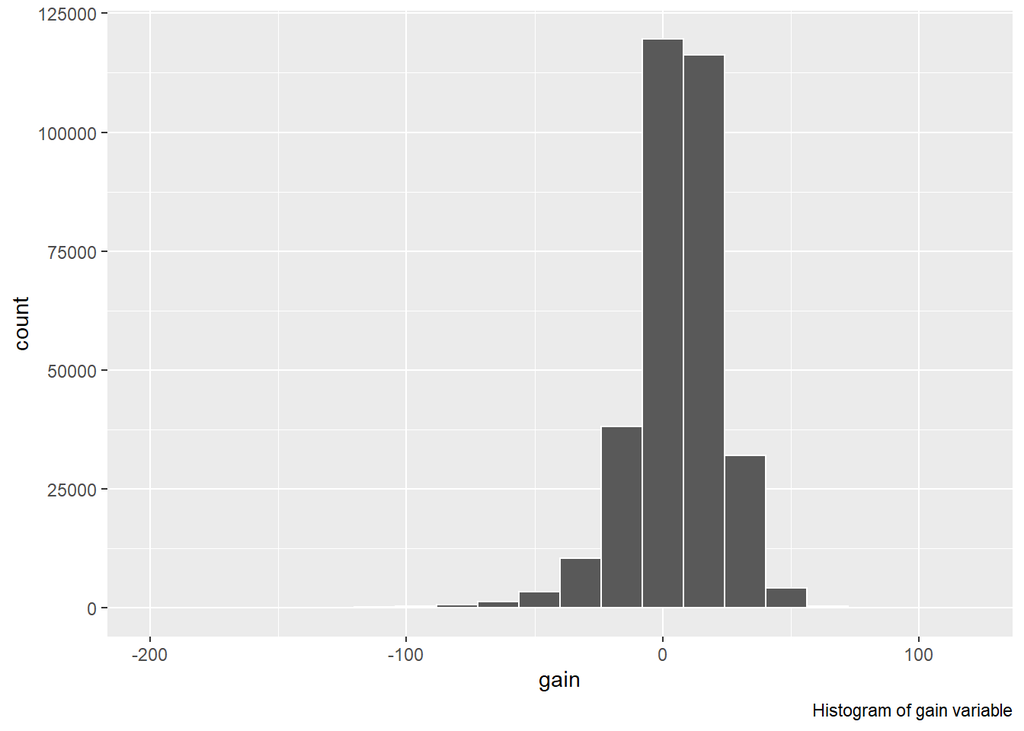

```r
ggplot(data = flights, mapping = aes(x = gain)) +
  geom_histogram(color = "white", bins = 20) +
  labs(caption="Histogram of gain variable")
```

```r
flights <- flights %>%
  mutate(
    gain = dep_delay - arr_delay,
    hours = air_time / 60,
    gain_per_hour = gain / hours
  )
```

## (LC4.11)

Could we create the dep_delay and arr_delay columns by simply subtracting dep_time from sched_dep_time and similarly for arrivals? Take a look at the values in those columns and comment on some challenges that you may encounter.

INSERT YOUR ANSWER HERE You would get negative numbers correct? It may be more prudent to subtract sched_dep_time from dep_time and same for arrivals.

# Sorting (arrange)

```r
freq_dest <- flights %>%
  group_by(dest) %>%
  summarize(num_flights = n())
freq_dest
```

```
## # A tibble: 105 x 2
##    dest  num_flights
##    <chr>       <int>
##  1 ABQ           254
##  2 ACK           265
##  3 ALB           439
##  4 ANC             8
##  5 ATL         17215
##  6 AUS          2439
##  7 AVL           275
##  8 BDL           443
##  9 BGR           375
## 10 BHM           297
## # ... with 95 more rows
```

```r
freq_dest %>%
  arrange(num_flights)
```

```
## # A tibble: 105 x 2
##    dest  num_flights
##    <chr>       <int>
##  1 LEX             1
##  2 LGA             1
##  3 ANC             8
##  4 SBN            10
##  5 HDN            15
##  6 MTJ            15
##  7 EYW            17
##  8 PSP            19
##  9 JAC            25
## 10 BZN            36
## # ... with 95 more rows
```

```r
freq_dest %>%
  arrange(desc(num_flights))
```

```
## # A tibble: 105 x 2
##    dest  num_flights
##    <chr>       <int>
##  1 ORD         17283
##  2 ATL         17215
##  3 LAX         16174
##  4 BOS         15508
##  5 MCO         14082
##  6 CLT         14064
##  7 SFO         13331
##  8 FLL         12055
##  9 MIA         11728
## 10 DCA          9705
## # ... with 95 more rows
```

## (LC 544.3.2)

Which airport from the `airports` dataframe has the highest altitude?

```r
# INSERT YOUR R CODE HERE
airports %>%
  arrange(desc(alt))
```

```
## # A tibble: 1,458 x 8
##    faa   name                        lat   lon   alt    tz dst   tzone
##    <chr> <chr>                     <dbl> <dbl> <dbl> <dbl> <chr> <chr>
##  1 TEX   Telluride                  38.0 -108.  9078    -7 A     America/Denver
##  2 TVL   Lake Tahoe Airport         38.9 -120.  8544    -8 A     America/Los_An~
##  3 ASE   Aspen Pitkin County Sard~  39.2 -107.  7820    -7 A     America/Denver
##  4 GUC   Gunnison - Crested Butte   38.5 -107.  7678    -7 A     America/Denver
##  5 BCE   Bryce Canyon               37.7 -112.  7590    -7 A     America/Denver
##  6 ALS   San Luis Valley Regional~  37.4 -106.  7539    -7 A     America/Denver
##  7 LAR   Laramie Regional Airport   41.3 -106.  7284    -7 A     America/Denver
##  8 LAM   Los Alamos Airport         35.9 -106.  7171    -7 A     America/Denver
##  9 EVW   Evanston-Uinta CO Burns ~  41.2 -111.  7143    -7 A     America/Denver
## 10 MMH   Mammoth Yosemite Airport   37.6 -119.  7128    -8 A     America/Los_An~
## # ... with 1,448 more rows
```

## Joining (inner_join)

```r
flights_joined <- flights %>%
 inner_join(airlines, by = "carrier")
```

```r
flights_with_airport_names <- flights %>%
 inner_join(airports, by = c("dest" = "faa"))
```

```r
named_dests <- flights %>%
  group_by(dest) %>%
  summarize(num_flights = n()) %>%
  arrange(desc(num_flights)) %>%
  inner_join(airports, by = c("dest" = "faa")) %>%
  rename(airport_name = name)
named_dests
```

```
## # A tibble: 101 x 9
##    dest  num_flights airport_name          lat    lon   alt    tz dst   tzone
##    <chr>       <int> <chr>               <dbl>  <dbl> <dbl> <dbl> <chr> <chr>
##  1 ORD         17283 Chicago Ohare Intl   42.0  -87.9   668    -6 A     America~
##  2 ATL         17215 Hartsfield Jackson~  33.6  -84.4  1026    -5 A     America~
##  3 LAX         16174 Los Angeles Intl     33.9 -118.    126    -8 A     America~
##  4 BOS         15508 General Edward Law~  42.4  -71.0    19    -5 A     America~
##  5 MCO         14082 Orlando Intl         28.4  -81.3    96    -5 A     America~
##  6 CLT         14064 Charlotte Douglas ~  35.2  -80.9   748    -5 A     America~
##  7 SFO         13331 San Francisco Intl   37.6 -122.     13    -8 A     America~
##  8 FLL         12055 Fort Lauderdale Ho~  26.1  -80.2     9    -5 A     America~
##  9 MIA         11728 Miami Intl           25.8  -80.3     8    -5 A     America~
## 10 DCA          9705 Ronald Reagan Wash~  38.9  -77.0    15    -5 A     America~
## # ... with 91 more rows
```

```r
flights_weather_joined <- flights %>%
 inner_join(weather, by = c("year", "month", "day", "hour", "origin"))
```

```r
joined_flights <- flights %>%
 inner_join(airlines, by = "carrier")
```

## (LC 544.3.3)

What’s the name of the airport that has the largest mean departure delay from any of the New York airports? Hint: Copy the code above where we created named_dests and modify it.

```r
# INSERT YOUR R CODE HERE
largest_dep_delay <- flights %>%
  group_by(origin) %>%
  summarize(mean_dep_delay = mean(dep_delay, na.rm = TRUE)) %>%
  arrange(desc(mean_dep_delay)) %>%
  inner_join(airports, by = c("origin" = "faa")) %>%
  rename(airport_name = name)
largest_dep_delay
```

```
## # A tibble: 3 x 9
##   origin mean_dep_delay airport_name       lat   lon   alt    tz dst   tzone
##   <chr>           <dbl> <chr>            <dbl> <dbl> <dbl> <dbl> <chr> <chr>
## 1 EWR              15.1 Newark Liberty ~  40.7 -74.2    18    -5 A     America/~
## 2 JFK              12.1 John F Kennedy ~  40.6 -73.8    13    -5 A     America/~
## 3 LGA              10.3 La Guardia        40.8 -73.9    22    -5 A     America/~
```

## Selecting

```r
flights %>%
 select(carrier, flight)
```

```
## # A tibble: 336,776 x 2
##    carrier flight
##    <chr>    <int>
##  1 UA        1545
##  2 UA        1714
##  3 AA        1141
##  4 B6         725
##  5 DL         461
##  6 UA        1696
##  7 B6         507
##  8 EV        5708
##  9 B6          79
## 10 AA         301
## # ... with 336,766 more rows
```

```r
flights_no_year <- flights %>%
 select(-year)
```

```r
flight_arr_times <- flights %>%
 select(month:day, arr_time:sched_arr_time)
```

```r
flights_reorder <- flights %>%
 select(year, month, day, hour, minute, time_hour, everything())
```

```r
flights_begin_a <- flights %>%
 select(starts_with("a"))
```

```r
flights_delays <- flights %>%
  select(ends_with("delay"))
```

```r
flights_time <- flights %>%
 select(contains("time"))
```

## Renaming

```r
flights_time_new <- flights %>%
 select(contains("time")) %>%
 rename(departure_time = dep_time,
        arrival_time = arr_time)
```

## Tidying

```r
library(fivethirtyeight)
```

```r
drinks
```

```
## # A tibble: 193 x 5
##    country      beer_servings spirit_servings wine_servings total_litres_of_pur~
##    <chr>                <int>           <int>         <int>                <dbl>
##  1 Afghanistan              0               0             0                  0
##  2 Albania                 89             132            54                  4.9
##  3 Algeria                 25               0            14                  0.7
##  4 Andorra                245             138           312                 12.4
##  5 Angola                 217              57            45                  5.9
##  6 Antigua & B~           102             128            45                  4.9
##  7 Argentina              193              25           221                  8.3
##  8 Armenia                 21             179            11                  3.8
##  9 Australia              261              72           212                 10.4
## 10 Austria                279              75           191                  9.7
## # ... with 183 more rows
```

```r
drinks_smaller <- drinks %>%
  filter(country %in% c("USA", "China", "Italy", "Saudi Arabia")) %>%
  select(-total_litres_of_pure_alcohol) %>%
  rename(beer = beer_servings, spirit = spirit_servings, wine = wine_servings)
drinks_smaller
```

```
## # A tibble: 4 x 4
##   country       beer spirit  wine
##   <chr>        <int>  <int> <int>
## 1 China           79    192     8
## 2 Italy           85     42   237
## 3 Saudi Arabia     0      5     0
## 4 USA            249    158    84
```

## (LC 544.3.4)

Add Canada to the list of countries in our drinks_smaller dataframe. You might just want to copy and paste the above code block and edit it instead of trying to actually add Canada to the existing drinks_smaller dataframe.

```r
# INSERT YOUR R CODE HERE
drinks_smaller <- drinks %>%
  filter(country %in% c("USA", "China", "Italy", "Saudi Arabia", "Canada")) %>%
  select(-total_litres_of_pure_alcohol) %>%
  rename(beer = beer_servings, spirit = spirit_servings, wine = wine_servings)
drinks_smaller
```

```
## # A tibble: 5 x 4
##   country       beer spirit  wine
##   <chr>        <int>  <int> <int>
## 1 Canada         240    122   100
## 2 China           79    192     8
## 3 Italy           85     42   237
## 4 Saudi Arabia     0      5     0
## 5 USA            249    158    84
```

```r
drinks_smaller_tidy <- drinks_smaller %>%
  gather(key = type, value = servings, c(beer, spirit, wine))
drinks_smaller_tidy
```

```
## # A tibble: 15 x 3
##    country      type   servings
##    <chr>        <chr>     <int>
##  1 Canada       beer        240
##  2 China        beer         79
##  3 Italy        beer         85
##  4 Saudi Arabia beer          0
##  5 USA          beer        249
##  6 Canada       spirit      122
##  7 China        spirit      192
##  8 Italy        spirit       42
##  9 Saudi Arabia spirit        5
## 10 USA          spirit      158
## 11 Canada       wine        100
## 12 China        wine          8
## 13 Italy        wine        237
## 14 Saudi Arabia wine          0
## 15 USA          wine         84
```

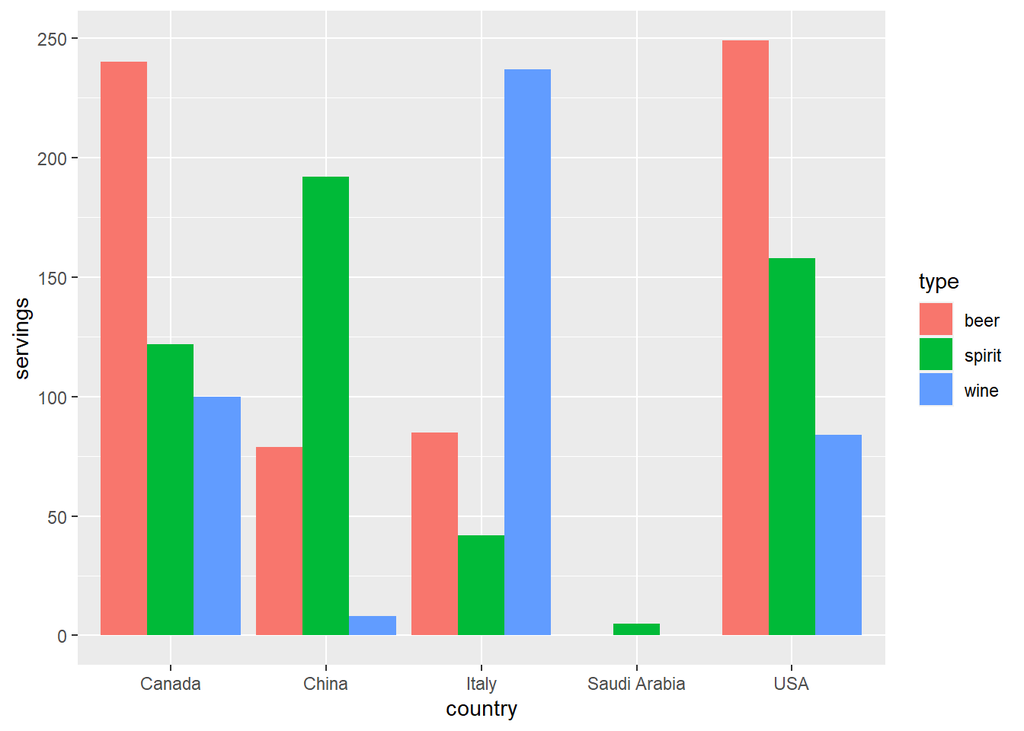

```r
ggplot(drinks_smaller_tidy,
       aes(x = country, y = servings, fill = type)) +
  geom_col(position = "dodge")
```

END OF NOTEBOOK